# Take-home Exercise 3

Putting Visual Analytics into Practical Use

Zhou Yiou https://example.com/zhouyiou (MITB SMU)https://example.com/spacelysprokets  
2022-02-20

## 1.0 About the task

This [take-home exercise](https://isss608-ay2021-22t2.netlify.app/th_ex/th_ex03) requires to apply appropriate data visualization techniques learned in Lesson 4 to accomplish the following task:

Create a data visualisation to provide an unbiased comparison of order returned by state.

For this task, Superstore-2021.xls should be used and the chart applied here are from [Hands-On Exercise 4: Building Funnel Plot with R](https://isss608-ay2021-22t2.netlify.app/hands-on_ex/hands-on_ex04/hands-on_ex04-funnelplot)

## 2.0 Installing and loading the required libraries

In this exercise, tidyverse, FunnelPlotR, plotly and Knitr will be used.

```r
packages = c('tidyverse', 'FunnelPlotR', 'plotly','dplyr',
             'knitr','readxl')
for(p in packages){
  if(!require(p,character.only = T)){
    install.packages(p)
  }
  library(p,character.only = T)
}
```

## 3.0 data wrangling

Importing data

```r
orders <- read_xls("data/Superstore-2021.xls",
                  sheet = "Orders")
returns <- read_xls("data/Superstore-2021.xls",
                  sheet = "Returns")
```

Join orders table and returns table

```r
store <- left_join(returns, orders,
                        by = c('Order ID' = 'Order ID'))%>%
mutate_if(is.character,as.factor)
glimpse(store)
```

```
Rows: 3,226
Columns: 22
$ Returned         <fct> Yes, Yes, Yes, Yes, Yes, Yes, Yes, Yes, Yes~
$ `Order ID`       <fct> CA-2018-100762, CA-2018-100762, CA-2018-100~
$ `Row ID`         <dbl> 6315, 6316, 6317, 6318, 6315, 6316, 6317, 6~
$ `Order Date`     <dttm> 2018-11-24, 2018-11-24, 2018-11-24, 2018-1~
$ `Ship Date`      <dttm> 2018-11-29, 2018-11-29, 2018-11-29, 2018-1~
$ `Ship Mode`      <fct> Standard Class, Standard Class, Standard Cl~
$ `Customer ID`    <fct> NG-18355, NG-18355, NG-18355, NG-18355, NG-~
$ `Customer Name`  <fct> Nat Gilpin, Nat Gilpin, Nat Gilpin, Nat Gil~
$ Segment          <fct> Corporate, Corporate, Corporate, Corporate,~
$ `Country/Region` <fct> United States, United States, United States~
$ City             <fct> Jackson, Jackson, Jackson, Jackson, Jackson~
$ State            <fct> Michigan, Michigan, Michigan, Michigan, Mic~
$ `Postal Code`    <dbl> 49201, 49201, 49201, 49201, 49201, 49201, 4~
$ Region           <fct> Central, Central, Central, Central, Central~
$ `Product ID`     <fct> OFF-AR-10000380, OFF-LA-10003930, OFF-PA-10~
$ Category         <fct> Office Supplies, Office Supplies, Office Su~
$ `Sub-Category`   <fct> Art, Labels, Paper, Paper, Art, Labels, Pap~
$ `Product Name`   <fct> "Hunt PowerHouse Electric Pencil Sharpener,~
$ Sales            <dbl> 151.920, 196.620, 144.120, 15.960, 151.920,~
$ Quantity         <dbl> 4, 2, 3, 2, 4, 2, 3, 2, 4, 2, 3, 2, 4, 2, 3~
$ Discount         <dbl> 0.0, 0.0, 0.0, 0.0, 0.0, 0.0, 0.0, 0.0, 0.0~
$ Profit           <dbl> 45.5760, 96.3438, 69.1776, 7.9800, 45.5760,~
```

```r
levels(store$Returned)
```

```
[1] "Yes"
```

Count the number of return by state.

```r
sr <- store %>%
  group_by(State)%>%
  summarise('Returned'=n())%>%
  ungroup()
sr
```

```
# A tibble: 36 x 2
   State      Returned
   <fct>         <int>
 1 Alabama           4
 2 Arizona          72
 3 California     1370
 4 Colorado         89
 5 Delaware         30
 6 Florida          45
 7 Georgia          24
 8 Idaho             4
 9 Illinois         72
10 Indiana           3
# ... with 26 more rows
```

count the number of orders by the state.

```
# A tibble: 49 x 2
   State                `Order ID`
   <chr>                     <int>
 1 Alabama                      61
 2 Arizona                     224
 3 Arkansas                     60
 4 California                 2001
 5 Colorado                    182
 6 Connecticut                  82
 7 Delaware                     96
 8 District of Columbia         10
 9 Florida                     383
10 Georgia                     184
# ... with 39 more rows
```

join two dataframe

```
# A tibble: 49 x 3
   State                `Order ID` Returned
   <chr>                     <int>    <int>
 1 Alabama                      61        4
 2 Arizona                     224       72
 3 Arkansas                     60       NA
 4 California                 2001     1370
 5 Colorado                    182       89
 6 Connecticut                  82       NA
 7 Delaware                     96       30
 8 District of Columbia         10       NA
 9 Florida                     383       45
10 Georgia                     184       24
# ... with 39 more rows
```

## 4.0 FunnelPlotR methods

order returned by state.(return rate by state?)

FunnelPlotR package uses ggplot to generate funnel plots. It requires a numerator (events of interest), denominator (population to be considered) and group. The key arguments selected for customisation are:

- limit: plot limits (95 or 99).
- label_outliers: to label outliers (true or false).
- Poisson_limits: to add Poisson limits to the plot.
- OD_adjust: to add overdispersed limits to the plot.
- xrange and yrange: to specify the range to display for axes, acts like a zoom function.
- Other aesthetic components such as graph title, axis labels etc.

### 4.1 FunnelPlotR methods: The basic plot

The code chunk below plots a funnel plot.

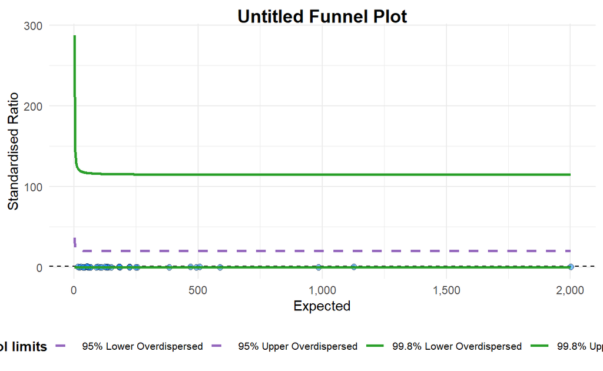

```
A funnel plot object with 49 points of which 0 are outliers.
Plot is adjusted for overdispersion.
```

```r
fp<-funnel_plot(
  numerator = ss$Returned,
  denominator = ss$`Order ID`,
  group = ss$State
)
fp
```

### 4.2 FunnelPlotR methods: Makeover 1

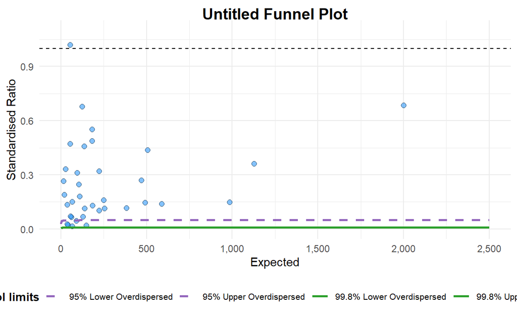

```
A funnel plot object with 49 points of which 0 are outliers.
Plot is adjusted for overdispersion.
```

### 4.3 FunnelPlotR methods: Makeover 2

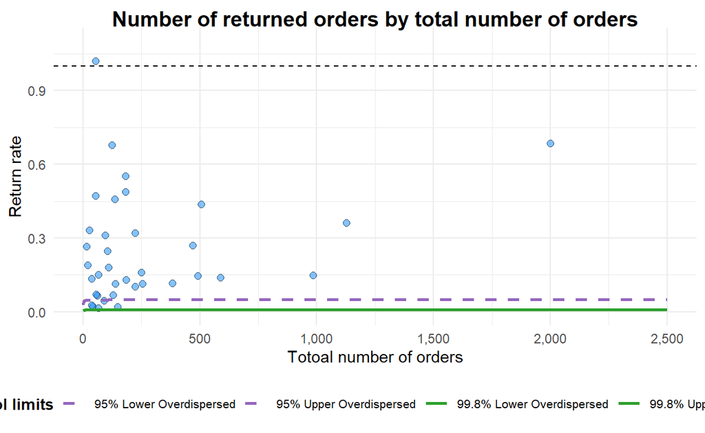

```
A funnel plot object with 49 points of which 0 are outliers.
Plot is adjusted for overdispersion.
```